# Team (github link: https://github.com/aashwinlamsal/ds202_lab2)

Eric Friesth, Aashwin Lamsal

9/13/2019

1 . Run the following code line by line to figure out what it’s doing. Then next to each line of code, write a comment explaining its purpose and function, including the use of any specific arguments. Comments in R are proceeded by a `#`, so that R knows not to run anything after the hashtag.

```r
recent_rating = choco[choco$Review.Date>2011,] # Assigns a data.frame of chocolate reviews newer than 2011 as 'recent_rating'

unique(recent_rating$Company.Location) # NOTICE: how many countries are listed but how many levels are there? 54 countries printed but 61 levels

recent_rating$Company.Location = droplevels(recent_rating$Company.Location) # This drops unused levels factors from a data frame

head(recent_rating) # shows us the first 6 records of the new 'recent_rating' of choco

cross_table = table(recent_rating$Review.Date,recent_rating$Company.Location) # Creates a table consisting of the count of reviews by country within the recent ratings (>2011)
cross_table # displays this table

which(cross_table[1,]!=0 & cross_table[2,]!=0 & cross_table[3,]!=0 & cross_table[4,]!=0 & cross_table[5,]!=0) # this code gives us all the countries that don't have a recent review of 0

france_recent = subset(recent_rating,Company.Location =='France') #makes a subset of the cross_table dataframe that only stores recent_ratings and company location that equal France
uk_recent = subset(recent_rating,Company.Location =='U.K.')#makes a subset of the cross_table dataframe that only stores recent_ratings and company location that equal U.K.
germany_recent = subset(recent_rating,Company.Location=='Germany') #makes a subset of the cross_table dataframe that only stores recent_ratings and company location that equal Germany

par(mfrow=c(2,2)) #par is used to set graphical parameters, with mfrow telling R to draw the figures in a column by row array, specifically by rows in our case, this creates 2x2 pictures on a square plotting region
color1 = ifelse(france_recent$Rating >median(france_recent$Rating), 'blue', 'green') #if else statement here determines the color for the specific points based on a rating criteria, where if the rating of a certain chocolate bar is greater than the median rating of all chocolate bars, it will be colored blue on the plot, and if the rating is below the media the color is green.
plot(france_recent$Cocoa.Pct ~ france_recent$Review.Date,ylim=c(50,90),col=color1,pch=18,cex=1.5,xlab="Review Date", ylab= "Cocoa Percentage", main= "France") #creates a plot with cocoa percentages on the y-axis and review dates on the x-axis.
legend('bottomright',legend=c('High Rating', 'Low Rating'),col=c('blue','green'),pch=18) # this creates a legend for the plot, that informs the user that High Rated chocolate bars are in blue, Low Rated chocolate bars are in green, with pch creating the plotting symbols that appear in the legend.

color2 = ifelse(uk_recent$Rating >median(uk_recent$Rating), 'purple', 'red') #if else statement here determines the color for the specific points based on a rating criteria, where if the rating of a certain chocolate bar is greater than the median rating of all chocolate bars, it will be colored purple on the plot, and if the rating is below the media the color is red.
plot(uk_recent$Cocoa.Pct ~ uk_recent$Review.Date,ylim=c(50,90),col=color2,pch=18,cex=1.5, xlab="Review Date", ylab= "Cocoa Percentage", main= "UK")  #creates a plot with cocoa percentages on the y-axis and review dates on the x-axis.
legend('bottomright',legend=c('High Rating', 'Low Rating'),col=c('purple','red'),pch=18) # this creates a legend for the plot, that informs the user that High Rated chocolate bars are in purple, Low Rated chocolate bars are in red, with pch creating the plotting symbols that appear in the legend.

color3 = ifelse(germany_recent$Rating > median(germany_recent$Rating), 'orange', 'yellow')#if else statement here determines the color for the specific points based on a rating criteria, where if the rating of a certain chocolate bar is greater than the median rating of all chocolate bars, it will be colored orange on the plot, and if the rating is below the media the color is yellow.
plot(germany_recent$Cocoa.Pct ~ germany_recent$Review.Date,ylim=c(50,90),col=color3,pch=18,cex=1.5,xlab="Review Date", ylab= "Cocoa Percentage", main= "Germany") #creates a plot with cocoa percentages on the y-axis and review dates on the x-axis.
legend('bottomright',legend=c('High Rating', 'Low Rating'),col=c('orange','yellow'),pch=18)# this creates a legend for the plot, that informs the user that High Rated chocolate bars are in orange, Low Rated chocolate bars are in yellow, with pch creating the plotting symbols that appear in the legend.
```

2 . Click Zoom on the Rstudio window (under Plots) to see the plot more clearly. How do you think the plot produced from the code above can be improved? Recommend at least one possible improvement.

The most apparent possible improvement to the plots would be to move the location of the legend, as it blocks some of the points in the lower righthand quadrant of the plots. Another improvement could be to have the individual ratings for each of the points appear on the plot, or at least explain the conditions behind what constitutes a high and low rating, since someone who is looking at these plots for the first time wouldn’t have a clear understanding of what makes a high or low rating.

3 . How does the **number** of ratings (not the actual value of the rating) depend on the year? Use graphics to answer this question.

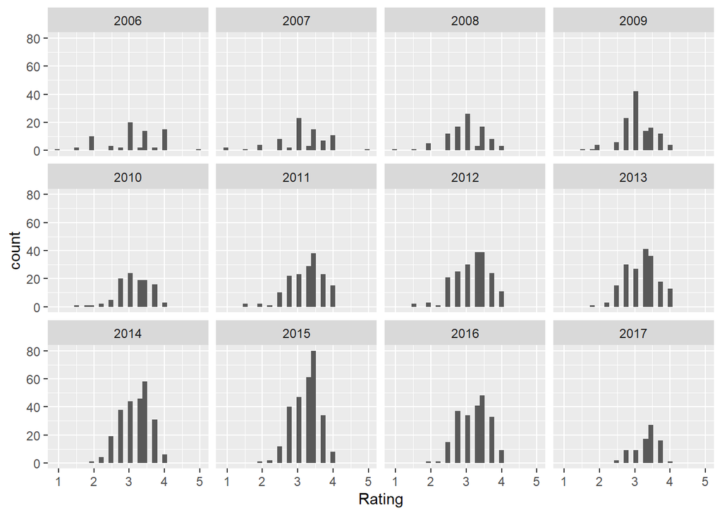

4 . How do ratings compare across different company locations? Focus on the three locations with the most ratings. Hint: the function `sort()` might come in handy here.

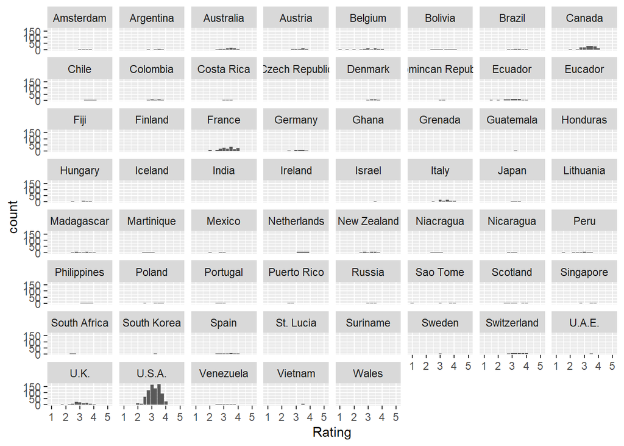

```
## [1] "USA:"
```

```
## [1] 787
```

```
## [1] "France:"
```

```
## [1] 158
```

```
## [1] "Canada:"
```

```
## [1] 132
```

```
## [1] "UK:"
```

```
## [1] 98
```

5 . Brainstorm and write down an interesting question that can be answer from the dataset. The question should not duplicate the questions above.

What are the entries that have a rating of 4.0 or greater?

6 . Bonus points (optional): Answer the question from the dataset.

```
##                                   Company
## 10                               A. Morin
## 14                               A. Morin
## 23                               A. Morin
## 60                                   AMMA
## 61                                  Amano
## 63                                  Amano
## 85                                 Amedei
## 86                                 Amedei
## 87                                 Amedei
## 92                                 Amedei
## 95                                 Amedei
## 96                                 Amedei
## 111                                 Arete
## 112                                 Arete
```

[output cut: 393 more lines]